# Part3 - Data Exploration and Visualization(2)

## III. Data Visualization

In this step, we will explore more about our data by utilizing data visualization. First, we want to investigate if there exists any features of the location of sending the disaster tweets. We plot several barplots here to achieve this goal. Then, we will do the analysis on the sentence level, word level, and character lever. We will visualize our analysis in these texts by plotting histograms to give a direct impression. Finally, we will plot 2 word clouds for the polpulation codded by target label. Then we may compare if there are any differences of the high frequency words between disaster tweets and non-disaster tweets.

##### Explore the target column distribution

```python
from IPython.core.interactiveshell import InteractiveShell
InteractiveShell.ast_node_interactivity = "all"

import numpy as np
import pandas as pd
import matplotlib.pyplot as plt

import seaborn as sns
import nltk
from string import punctuation
from wordcloud import WordCloud
```

```python
train = pd.read_csv("train.csv")
test = pd.read_csv("test.csv")
```

```python
#count the number of keyword
keyword = train['keyword'].value_counts()
keyword.head(20)
```

```
fatalities     45
deluge         42
armageddon     42
sinking        41
damage         41
harm           41
body%20bags    41
outbreak       40
evacuate       40
fear           40
collided       40
siren          40
twister        40
windstorm      40
sinkhole       39
sunk           39
hellfire       39
weapon         39
weapons        39
famine         39
Name: keyword, dtype: int64
```

```
[Text(0.5, 0, 'location appearance counts')]
```

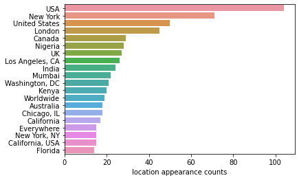

```python
ax = sns.barplot(train['location'].value_counts()[:20], train['location'].value_counts().index[:20])
ax.set(xlabel="location appearance counts")
```

[output not shown]

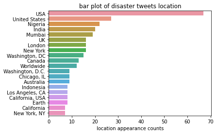

```python
train_dis = train[train['target']==1]
ax = sns.barplot(train_dis['location'].value_counts()[:20], train_dis['location'].value_counts().index[:20])
ax.set(xlabel="location appearance counts", title="bar plot of disaster tweets location")
```

[output not shown]

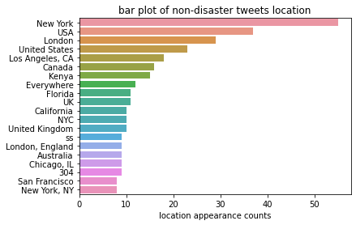

```python
train_non = train[train['target']==0]
ax = sns.barplot(train_non['location'].value_counts()[:20], train_non['location'].value_counts().index[:20])
ax.set(xlabel="location appearance counts", title="bar plot of non-disaster tweets location")
```

[output not shown]

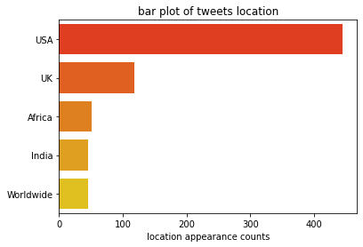

```python
#Renaming location names
train['location'].replace({'United States':'USA',
                           'New York':'USA',
                            "London":'UK',
                            "Los Angeles, CA":'USA',
                            "Washington, D.C.":'USA',
                            "California":'USA',
                             "Chicago, IL":'USA',
                             "Chicago":'USA',
                            "New York, NY":'USA',
                            "California, USA":'USA',
                            "FLorida":'USA',
                            "Nigeria":'Africa',
                            "Kenya":'Africa',
                            "Everywhere":'Worldwide',
                            "San Francisco":'USA',
                            "Florida":'USA',
                            "United Kingdom":'UK',
                            "Los Angeles":'USA',
                            "Toronto":'Canada',
                            "San Francisco, CA":'USA',
                            "NYC":'USA',
                            "Seattle":'USA',
                            "Earth":'Worldwide',
                            "Ireland":'UK',
                            "London, England":'UK',
                            "New York City":'USA',
                            "Texas":'USA',
                            "London, UK":'UK',
                            "Atlanta, GA":'USA',
                            "Mumbai":"India"},inplace=True)
ax = sns.barplot(y = train['location'].value_counts()[:5].index, x = train['location'].value_counts()[:5],
            palette='autumn', orient='h')
ax.set(xlabel="location appearance counts", title="bar plot of tweets location")
```

[output not shown]

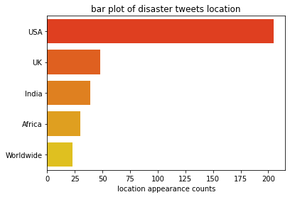

```python
#Renaming location names
train_dis['location'].replace({'United States':'USA',
                           'New York':'USA',
                            "London":'UK',
                            "Los Angeles, CA":'USA',
                            "Washington, D.C.":'USA',
                            "California":'USA',
                             "Chicago, IL":'USA',
                             "Chicago":'USA',
                            "New York, NY":'USA',
                            "California, USA":'USA',
                            "FLorida":'USA',
                            "Nigeria":'Africa',
                            "Kenya":'Africa',
                            "Everywhere":'Worldwide',
                            "San Francisco":'USA',
                            "Florida":'USA',
                            "United Kingdom":'UK',
                            "Los Angeles":'USA',
                            "Toronto":'Canada',
                            "San Francisco, CA":'USA',
                            "NYC":'USA',
                            "Seattle":'USA',
                            "Earth":'Worldwide',
                            "Ireland":'UK',
                            "London, England":'UK',
                            "New York City":'USA',
                            "Texas":'USA',
                            "London, UK":'UK',
                            "Atlanta, GA":'USA',
                            "Mumbai":"India"},inplace=True)
ax = sns.barplot(y = train_dis['location'].value_counts()[:5].index, x = train_dis['location'].value_counts()[:5],
            palette='autumn', orient='h')
ax.set(xlabel="location appearance counts", title="bar plot of disaster tweets location")
```

[output not shown]

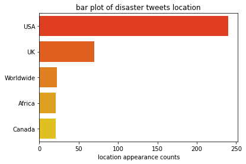

```python
#Renaming location names
train_non['location'].replace({'United States':'USA',
                           'New York':'USA',
                            "London":'UK',
                            "Los Angeles, CA":'USA',
                            "Washington, D.C.":'USA',
                            "California":'USA',
                             "Chicago, IL":'USA',
                             "Chicago":'USA',
                            "New York, NY":'USA',
                            "California, USA":'USA',
                            "FLorida":'USA',
                            "Nigeria":'Africa',
                            "Kenya":'Africa',
                            "Everywhere":'Worldwide',
                            "San Francisco":'USA',
                            "Florida":'USA',
                            "United Kingdom":'UK',
                            "Los Angeles":'USA',
                            "Toronto":'Canada',
                            "San Francisco, CA":'USA',
                            "NYC":'USA',
                            "Seattle":'USA',
                            "Earth":'Worldwide',
                            "Ireland":'UK',
                            "London, England":'UK',
                            "New York City":'USA',
                            "Texas":'USA',
                            "London, UK":'UK',
                            "Atlanta, GA":'USA',
                            "Mumbai":"India"},inplace=True)
ax = sns.barplot(y = train_non['location'].value_counts()[:5].index, x = train_non['location'].value_counts()[:5],
            palette='autumn', orient='h')
ax.set(xlabel="location appearance counts", title="bar plot of disaster tweets location")
```

Although it is our raw data that location names include city and country, we still can tell that American users are more likely to mark their location info, no matter disaster or not.

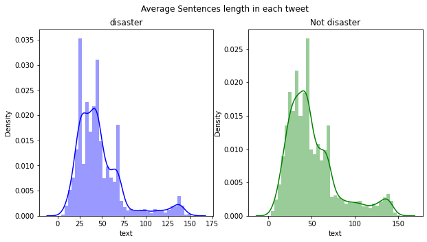

```python
fig,(ax1,ax2)=plt.subplots(1,2,figsize=(10,5))
sent=train[train['target']==1]['text'].str.split(".").apply(lambda x : [len(i) for i in x])
sns.distplot(sent.map(lambda x: np.mean(x)),ax=ax1,color='b')
ax1.set_title('disaster')
sent=train[train['target']==0]['text'].str.split(".").apply(lambda x : [len(i) for i in x])
sns.distplot(sent.map(lambda x: np.mean(x)),ax=ax2,color='green')
ax2.set_title('Not disaster')
fig.suptitle('Average Sentences length in each tweet')
```

[figure not shown]

```python
fig,(ax1,ax2)=plt.subplots(1,2,figsize=(10,5))
sent=train[train['target']==1]['text'].str.split().apply(lambda x : [len(i) for i in x])
sns.distplot(sent.map(lambda x: np.mean(x)),ax=ax1,color='b')
ax1.set_title('disaster')
sent=train[train['target']==0]['text'].str.split().apply(lambda x : [len(i) for i in x])
sns.distplot(sent.map(lambda x: np.mean(x)),ax=ax2,color='green')
ax2.set_title('Not disaster')
fig.suptitle('Average Words length in each tweet')
```

##### Explore number of characters in tweets encoded by target 0 or 1

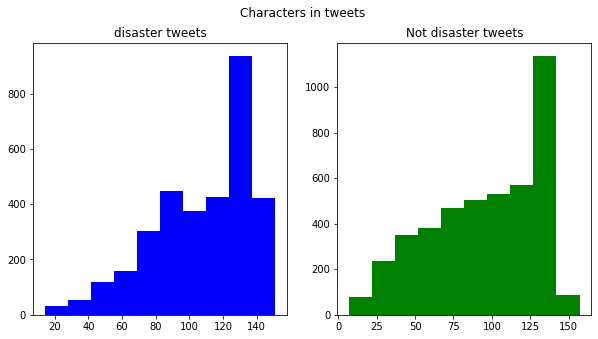

```python
fig,(ax1,ax2)=plt.subplots(1,2,figsize=(10,5))
train_len=train[train['target']==1]['text'].str.len()
ax1.hist(train_len,color='blue')
ax1.set_title('disaster tweets')
train_len=train[train['target']==0]['text'].str.len()
ax2.hist(train_len,color='green')
ax2.set_title('Not disaster tweets')
fig.suptitle('Characters in tweets')
plt.show()
```

Based on our analysis and visualizations, we can easily find that for the group of disaster tweets and the group of non-disaster tweets, they have similar features in on the sentence level, word level, and character level analysis.

##### Word Clouds

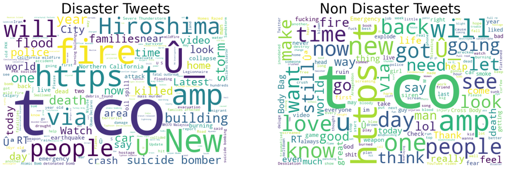

```python
fig, (ax1, ax2) = plt.subplots(1, 2, figsize=[26, 8])
p1 = WordCloud( background_color='white',
                        width=600,
                        height=400).generate(" ".join(train[train['target']==1]["text"]))
ax1.imshow(p1)
ax1.axis('off')
ax1.set_title('Disaster Tweets',fontsize=40);

p2 = WordCloud( background_color='white',
                        width=600,
                        height=400).generate(" ".join(train[train['target']==0]["text"]))
ax2.imshow(p2)
ax2.axis('off')
ax2.set_title('Non Disaster Tweets',fontsize=40);
```